# 02. DAY 1 EDA와 모델 설계 전략

SKALA 3반 · U095 · 이연주 | 2026-10-01

**문제:** 초기 100사이클의 관측으로 배터리의 전체 사이클 수명을 예측할 수 있는가? **목표:** Batch별 다섯 질문 분석 → 관찰 → 해석 → 피처와 모델 전략.

이 노트북만 Run All 해도 모든 분석 표·그림을 다시 만들 수 있다. 데이터 지문은 `01_data_check.ipynb`에서 생성한다. 분석용 함수는 `src/day1_analysis.py`, 보완 분석은 `src/day1_review.py`에 모았다. Scratch의 변수·출력·실행 상태를 참조하지 않으며 원본 MAT 파일에서 독립 계산한다. 아래 셀은 순서대로 실행하며, 모델 성능은 아직 계산하지 않는다. 데이터 범위와 품질 규칙은 `01_data_check.ipynb`와 같다.

```python
from pathlib import Path
import sys, os
ROOT = Path(os.environ.get("ESS_PROJECT_ROOT", Path.cwd())).resolve()
if ROOT.name == "notebooks": ROOT = ROOT.parent
assert (ROOT / "data").exists(), "프로젝트 루트에서 실행한다."
sys.path.insert(0, str(ROOT / "src"))
import numpy as np
import pandas as pd
import matplotlib.pyplot as plt
from IPython.display import display, Markdown
import day1_analysis as da
import day1_review as review
da.configure()
OUT = ROOT / "results" / "day1"
(OUT / "tables").mkdir(parents=True, exist_ok=True)
(OUT / "figures").mkdir(parents=True, exist_ok=True)
pd.set_option("display.max_columns", 30)
pd.set_option("display.max_colwidth", 90)
print("프로젝트:", ROOT)
print("random_state =", da.RANDOM_STATE)
```

```
프로젝트: /Users/yeonju/workspace/데이터 분석 mini-Project/ess-battery-project
random_state = 42
```

```python
cells, manifest = da.load_batches(ROOT / "data")
features, quality = da.feature_table(cells)
summary, corr = da.make_tables(cells, features, quality, manifest, OUT)
display(summary.round(3))
```

|  | batch | cells | labels | missing_labels | cycles | policies | min | q25 | median | mean | q75 | max | std | short_n | long_n | short_pct | long_pct | below550 | above_eq550 | valid_dq | eligible |
| --- | --- | --- | --- | --- | --- | --- | --- | --- | --- | --- | --- | --- | --- | --- | --- | --- | --- | --- | --- | --- | --- |
| 0 | Batch 1 | 46 | 46 | 0 | 38811 | 23 | 534.0 | 703.25 | 858.5 | 844.717 | 914.25 | 1227.0 | 184.629 | 0 | 10 | 0.000 | 21.739 | 1 | 45 | 46 | 36 |
| 1 | Batch 2 | 47 | 39 | 8 | 26904 | 20 | 392.0 | 439.50 | 472.0 | 565.744 | 508.50 | 1186.0 | 222.202 | 28 | 3 | 71.795 | 7.692 | 30 | 9 | 47 | 39 |
| 2 | Batch 3 | 46 | 44 | 2 | 51007 | 8 | 541.0 | 828.00 | 1005.5 | 1059.659 | 1155.25 | 1935.0 | 313.870 | 0 | 23 | 0.000 | 52.273 | 1 | 43 | 46 | 40 |

## Q1. Cycle Life 분포는 어떻게 생겼는가?

수명 NaN은 히스토그램의 분모에서 제외한다. `<500` 단수명, `500~1000` 중간수명, `>1000` 장수명이다. 과제의 150~2,300 축을 유지하되 현재 유효 정답의 실제 범위와 구분한다.

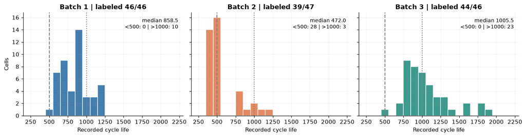

|  | batch | labels | missing_labels | min | median | mean | max | short_n | short_pct | long_n | long_pct |
| --- | --- | --- | --- | --- | --- | --- | --- | --- | --- | --- | --- |
| 0 | Batch 1 | 46 | 0 | 534.0 | 858.5 | 844.72 | 1227.0 | 0 | 0.00 | 10 | 21.74 |
| 1 | Batch 2 | 39 | 8 | 392.0 | 472.0 | 565.74 | 1186.0 | 28 | 71.79 | 3 | 7.69 |
| 2 | Batch 3 | 44 | 2 | 541.0 | 1005.5 | 1059.66 | 1935.0 | 0 | 0.00 | 23 | 52.27 |

```python
da.fig_distribution(features, OUT)
plt.show()
display(summary[["batch", "labels", "missing_labels", "min", "median", "mean", "max", "short_n", "short_pct", "long_n", "long_pct"]].round(2))
```

**관찰:** 중앙값은 Batch 1=858.5, Batch 2=472.0, Batch 3=1005.5이다. Batch 2는 유효 39개 중 28개(71.8%)가 500 미만이다. Batch 1·3에는 500 미만이 없다.

**해석:** 제공된 Batch는 동일한 수명 분포에서 무작위로 나뉜 집합이 아니다. 평균 성능 한 숫자로 일반화를 판단하기 어렵다. 150~2,300은 과제의 축 범위이지 현재 파일의 실제 최솟값·최댓값이 아니다(392~1,935).

**시사점:** 회귀 오차를 Batch별·수명 구간별로 보고한다. 품질 점검 후 Batch 1의 최대 수명이 1,074이므로 Batch 3 장수명은 외삽 문제이다.

```python
shortest = features[features.analysis_eligible].sort_values("cycle_life").groupby("batch").head(1)
display(shortest[["cell_id", "cycle_life", "policy", "qd_slope", "log_dq_var", "tavg_median", "ir_median"]])
outliers = pd.read_csv(OUT / "tables/lifetime_outliers.csv")
display(outliers.groupby(["batch", "iqr_flag"]).size().rename("cells"))
display(outliers[outliers.iqr_flag.ne("within")])
```

|  | cell_id | cycle_life | policy | qd_slope | log_dq_var | tavg_median | ir_median |
| --- | --- | --- | --- | --- | --- | --- | --- |
| 65 | b2c19 | 392.0 | 6C(60%)-3C | 0.000022 | -3.291523 | 32.788667 | 0.016701 |
| 20 | b1c20 | 534.0 | 5.4C(80%)-5.4C | -0.000140 | -3.366803 | 32.112584 | 0.015165 |
| 121 | b3c28 | 541.0 | 3.7C(31%)-5.9C-newstructure | -0.000198 | -3.451223 | 35.708879 | 0.013437 |

```
batch    iqr_flag
Batch 1  within      46
Batch 2  high         9
         within      30
Batch 3  high         3
         within      41
Name: cells, dtype: int64
```

|  | cell_id | batch | cycle_life | iqr_lower | iqr_upper | iqr_flag | policy |
| --- | --- | --- | --- | --- | --- | --- | --- |
| 53 | b2c7 | Batch 2 | 777.0 | 336.000 | 612.000 | high | 4.8C(80%)-4.8C-newstructure |
| 54 | b2c8 | Batch 2 | 904.0 | 336.000 | 612.000 | high | 5.2C(58%)-4C-newstructure |
| 55 | b2c9 | Batch 2 | 791.0 | 336.000 | 612.000 | high | 5.6C(26%)-4.5C-newstructure |
| 76 | b2c32 | Batch 2 | 809.0 | 336.000 | 612.000 | high | 4.8C(80%)-4.8C-newstructure |
| 77 | b2c33 | Batch 2 | 1140.0 | 336.000 | 612.000 | high | 5.2C(58%)-4C-newstructure |
| 78 | b2c34 | Batch 2 | 1186.0 | 336.000 | 612.000 | high | 5.6C(26%)-4.5C-newstructure |
| 81 | b2c43 | Batch 2 | 1029.0 | 336.000 | 612.000 | high | 4.8C(80%)-4.8C-newstructure |
| 82 | b2c44 | Batch 2 | 841.0 | 336.000 | 612.000 | high | 5.2C(58%)-4C-newstructure |
| 83 | b2c45 | Batch 2 | 997.0 | 336.000 | 612.000 | high | 5.6C(26%)-4.5C-newstructure |
| 92 | b3c7 | Batch 3 | 1836.0 | 337.125 | 1646.125 | high | 4.8C(80%)-4.8C-newstructure |
| 121 | b3c38 | Batch 3 | 1935.0 | 337.125 | 1646.125 | high | 5C(67%)-4C-newstructure |
| 128 | b3c45 | Batch 3 | 1801.0 | 337.125 | 1646.125 | high | 4.8C(80%)-4.8C-newstructure |

**짧은 셀 점검:** b1c20(534), b2c19(392), b3c28(541)을 유지하고 초기 기울기·ΔQ·온도·정책을 함께 본다. b2c19는 초기 용량 기울기가 양수인데도 수명이 짧다. 초기 용량이 증가한다고 장수한다고 단정할 수 없다. 이 자료만으로 개별 셀의 고장 원인을 확정하지 않는다.

**통계적 이상치:** Batch별 Q1-1.5×IQR / Q3+1.5×IQR 기준에서 하위 이상치는 0개이다. 상위는 Batch 1=0, Batch 2=9, Batch 3=3개이다. Batch 2의 상위 9개는 모두 newstructure 조건이다. 이는 다른 하위 집단의 가능성을 보여주며 자동 삭제하지 않는다. '단수명(<500)'과 '통계적 이상치'는 서로 다른 기준이다.

**최단 셀의 상대적 위치:** 다음 표는 각 Batch 최단 셀의 초기 신호를 해당 Batch 중앙값 및 같은 정책의 다른 셀과 비교한다. 백분위는 해당 값 이하인 셀 비율이다. ΔQ 로그분산은 Batch 내 97.2/82.1/100백분위이다. b1c20·b2c19와 같은 정책의 다른 셀도 각각 559·408사이클로 짧아 충전 조건과의 관련 가능성이 있다. b3c28의 Tavg는 35.71°C로 Batch 중앙값 34.13°C보다 높다. 대조 실험이 아니므로 원인 증명이 아니라 열화 위험 신호를 좁히는 근거이다.

```python
review.evidence_tables(features, OUT)
display(pd.read_csv(OUT / "tables/shortest_cell_comparison.csv").round(4))
```

|  | batch | cell_id | cycle_life | feature | value | batch_median | percentile_le | other_same_policy_n | other_same_policy_life_median |
| --- | --- | --- | --- | --- | --- | --- | --- | --- | --- |
| 0 | Batch 1 | b1c20 | 534.0 | log_dq_var | -3.3668 | -3.7860 | 97.2222 | 1 | 559.0 |
| 1 | Batch 1 | b1c20 | 534.0 | qd_slope | -0.0001 | -0.0000 | 2.7778 | 1 | 559.0 |
| 2 | Batch 1 | b1c20 | 534.0 | tavg_median | 32.1126 | 32.9978 | 25.0000 | 1 | 559.0 |
| 3 | Batch 1 | b1c20 | 534.0 | ir_median | 0.0152 | 0.0166 | 5.5556 | 1 | 559.0 |
| 4 | Batch 2 | b2c19 | 392.0 | log_dq_var | -3.2915 | -3.4868 | 82.0513 | 1 | 408.0 |
| 5 | Batch 2 | b2c19 | 392.0 | qd_slope | 0.0000 | 0.0000 | 51.2821 | 1 | 408.0 |
| 6 | Batch 2 | b2c19 | 392.0 | tavg_median | 32.7887 | 33.0190 | 41.0256 | 1 | 408.0 |
| 7 | Batch 2 | b2c19 | 392.0 | ir_median | 0.0167 | 0.0165 | 53.8462 | 1 | 408.0 |
| 8 | Batch 3 | b3c28 | 541.0 | log_dq_var | -3.4512 | -4.1505 | 100.0000 | 2 | 719.5 |
| 9 | Batch 3 | b3c28 | 541.0 | qd_slope | -0.0002 | -0.0000 | 5.0000 | 2 | 719.5 |
| 10 | Batch 3 | b3c28 | 541.0 | tavg_median | 35.7089 | 34.1282 | 90.0000 | 2 | 719.5 |
| 11 | Batch 3 | b3c28 | 541.0 | ir_median | 0.0134 | 0.0154 | 2.5000 | 2 | 719.5 |

## Q2. 방전용량은 어떻게 감소하는가?

전체 궤적은 EDA에 사용한다. 색은 실제 기록된 수명에 연결하며 NaN 정답은 회색이다. EOL 참고선은 논문 공칭용량 1.1 Ah의 80%인 **0.88 Ah**이다. 제공 정답을 이 선으로 임의 재계산하지 않는다.

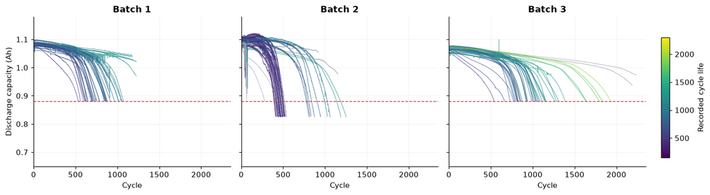

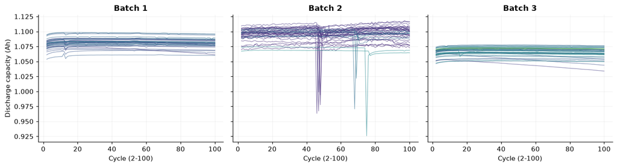

|  | batch | n | raw_slope_life_r | smoothed_slope_life_r | cells_with_local_deviation |
| --- | --- | --- | --- | --- | --- |
| 0 | Batch 1 | 36 | 0.508 | 0.511 | 0 |
| 1 | Batch 2 | 39 | -0.445 | -0.389 | 8 |
| 2 | Batch 3 | 40 | 0.331 | 0.331 | 0 |

```python
da.fig_degradation(cells, features, OUT)
plt.show()
da.fig_early(cells, features, OUT)
plt.show()
display(review.slope_sensitivity(cells, features, OUT).round(3))
```

**관찰:** 초기에는 궤적이 겹치며 일부 셀은 용량이 증가한다. 이후 많은 셀에서 감소가 가속된다. Batch 1에는 종료 시에도 높은 용량을 유지하는 셀이 있다.

**해석:** 전체 종료 시점을 모든 셀에서 동일하게 확인했다고 볼 수 없다. 0 또는 과도한 용량을 연결하면 선이 왜곡되므로 품질 규칙 밖 값은 NaN으로 끊었다. Batch 2 일부 초기 곡선에는 급락 후 복귀가 있다. 범위 안의 값을 자동 삭제하지 않고, 초기 2~100사이클에만 11점 이동 중앙값을 적용한 기울기와 원래 기울기의 상관을 비교했다. 순간 변화는 지속적인 열화와 구분해야 한다. 0.02 Ah 편차는 탐색용 표시 기준이며 고장 판정 기준이 아니다.

**시사점:** 초기 용량 단독보다 변화량·ΔQ 형태를 고려한다. 전체 곡선의 knee와 마지막 용량은 미래 정보이므로 입력 피처로 사용하지 않는다.

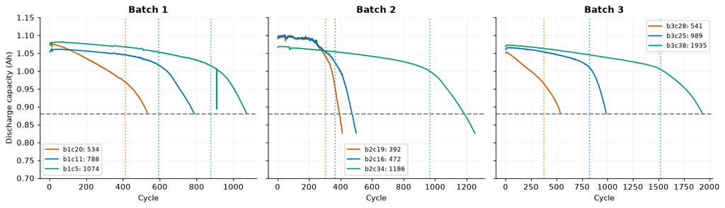

|  | cell_id | cycle_life | knee_cycle | slope_before | slope_after | knee_gain | knee_accepted |
| --- | --- | --- | --- | --- | --- | --- | --- |
| 5 | b1c5 | 1074.0 | 878.27273 | -0.00007 | -0.00069 | 0.94252 | True |
| 11 | b1c11 | 788.0 | 594.31818 | -0.00006 | -0.00073 | 0.97151 | True |
| 20 | b1c20 | 534.0 | 413.19659 | -0.00027 | -0.00071 | 0.89912 | True |
| 62 | b2c16 | 472.0 | 365.33636 | -0.00018 | -0.00152 | 0.92635 | True |
| 65 | b2c19 | 392.0 | 304.13636 | -0.00012 | -0.00205 | 0.94357 | True |
| 80 | b2c34 | 1186.0 | 964.83864 | -0.00006 | -0.00062 | 0.98062 | True |
| 118 | b3c25 | 989.0 | 824.24773 | -0.00006 | -0.00079 | 0.96277 | True |
| 121 | b3c28 | 541.0 | 377.52500 | -0.00023 | -0.00049 | 0.94851 | True |
| 131 | b3c38 | 1935.0 | 1521.04091 | -0.00004 | -0.00029 | 0.97235 | True |

```python
da.fig_representatives(cells, features, OUT)
plt.show()
rep = features[features.cell_id.isin(da.representatives(features))]
display(rep[["cell_id", "cycle_life", "knee_cycle", "slope_before", "slope_after", "knee_gain", "knee_accepted"]].round(5))
```

**Knee 방법:** 주분석 집합에서 Batch별 최단·중앙 순위·최장 셀을 선택한다. 11점 이동 중앙값에 연속된 두 직선을 맞춰 SSE가 가장 작아지는 지점을 찾는다. 단일 직선 대비 SSE 25% 이상 감소, 후기 기울기 더 음수, 후기 기울기 < -0.0001 Ah/cycle이면 후보로 표시한다.

점선은 알고리즘상 변화점 후보이다. 물리적 열화 기전이나 정확한 knee의 정답이 아니며 평활화·구간 선택에 민감하다. Batch 1·3의 최단 대표는 500 미만 셀이 아니므로 '단수명(<500)'으로 부르지 않는다.

## Q3. ΔQ(V)는 초기 사이클에서 차이를 보이는가?

동일한 전압축에서 `ΔQ = Q100 - Q10`을 계산한다. 리스트 번호 10을 곧 사이클 10으로 쓰지 않고 실제 summary.cycle로 위치를 찾는다. 분산은 표본분산(ddof=1), 왜도는 bias=False, 첨도는 초과첨도, 면적은 전압축을 오름차순으로 정렬해 적분한다.

```
예시 셀: b1c0 log10 Var(ΔQ) = -5.0144265311867695
```

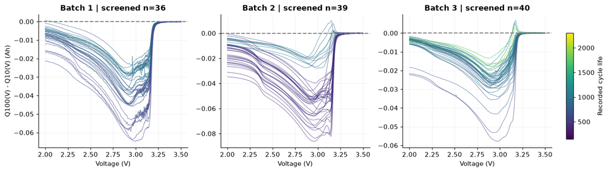

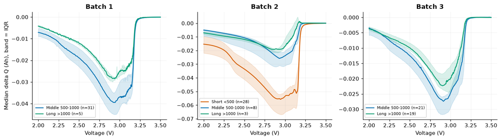

```python
# 핵심 식을 한 셀에서 직접 확인한다. 전체 계산은 같은 식을 적용한다.
example = cells[0]
delta_q = example["qcurves"][100] - example["qcurves"][10]
assert len(delta_q) == 1000
check = np.log10(np.var(delta_q, ddof=1))
assert np.isclose(check, features.loc[features.cell_id.eq(example["cell_id"]), "log_dq_var"].iloc[0])
print("예시 셀:", example["cell_id"], "log10 Var(ΔQ) =", check)
da.fig_delta(cells, features, OUT)
plt.show()
da.fig_delta_groups(cells, features, OUT)
plt.show()
```

**관찰:** ΔQ의 형태와 퍼짐이 셀마다 다르다. Batch 2는 단수명/장수명 집단을 직접 비교할 수 있지만, Batch 1·3은 단수명(<500) 집단이 없어 중간/장수명으로 비교한다. 음영은 집단의 IQR이며 신뢰구간이 아니다.

**해석:** 전압에 따른 용량 변화가 초기 총용량에 드러나지 않는 차이를 담는다. 다만 상관관계는 인과관계도 모델 성능도 아니다.

**시사점:** `log_dq_var`를 핵심 피처로 선정한다. ΔQ 평균·면적·표준편차를 무조건 모두 넣지 않고 중복을 점검한다.

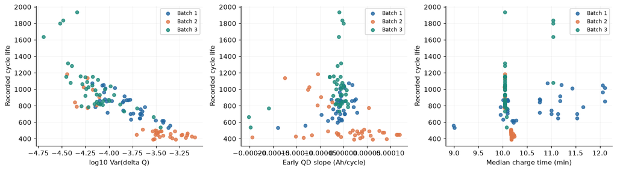

|  | scope | batch | feature | n | pearson | spearman |
| --- | --- | --- | --- | --- | --- | --- |
| 0 | all_labeled | Pooled | log_dq_var | 129 | -0.851 | -0.892 |
| 19 | all_labeled | Batch 1 | log_dq_var | 46 | -0.886 | -0.871 |
| 38 | all_labeled | Batch 2 | log_dq_var | 39 | -0.902 | -0.709 |
| 57 | all_labeled | Batch 3 | log_dq_var | 44 | -0.702 | -0.797 |
| 76 | quality_screened | Pooled | log_dq_var | 115 | -0.857 | -0.879 |
| 95 | quality_screened | Batch 1 | log_dq_var | 36 | -0.827 | -0.826 |
| 114 | quality_screened | Batch 2 | log_dq_var | 39 | -0.902 | -0.709 |
| 133 | quality_screened | Batch 3 | log_dq_var | 40 | -0.742 | -0.759 |

|  | batch | n_cells | n_policy_groups | pearson | bootstrap_lo | bootstrap_hi |
| --- | --- | --- | --- | --- | --- | --- |
| 0 | Batch 1 | 36 | 20 | -0.827 | -0.921 | -0.659 |
| 1 | Batch 2 | 39 | 12 | -0.902 | -0.929 | -0.442 |
| 2 | Batch 3 | 40 | 8 | -0.742 | -0.858 | -0.567 |

```python
da.fig_feature_scatter(features, OUT)
plt.show()
display(corr[corr.feature.eq("log_dq_var")].round(3))
da.supplementary_tables(features, corr, OUT)
display(pd.read_csv(OUT / "tables/delta_correlation_uncertainty.csv").round(3))
```

**안정성:** 품질 점검 후 ΔQ 로그분산의 Pearson r은 -0.827/-0.902/-0.742, Spearman ρ는 -0.826/-0.709/-0.759이다. 방향이 세 Batch에서 유지된다. 정책 단위 군집 부트스트랩 1,000회(난수 42) 구간도 저장했다. 정책 수가 적으므로 구간 역시 탐색적인 불확실성 표현이다. 모든 유효 정답을 사용한 결과와 품질 점검 후 결과는 `correlations.csv`에서 대조할 수 있다.

**Batch 내부 상대 비교 보완:** 절대 기준 <500이 없는 Batch 1·3도 수명 하위/상위 25% 곡선을 비교한다. 이는 과제의 단수명/장수명 정의를 바꾸는 것이 아니라 보충 분석이다. 세 Batch에서 하위 집단의 로그분산 중앙값이 더 높고, 곡선의 전압별 변화가 더 크다는 신호를 확인한다. 표본 수·컷오프·범위와 IQR을 함께 제시한다. 그룹 분리는 전체 수명 정답을 사용하는 EDA이며 모델 입력에는 사용하지 않는다.

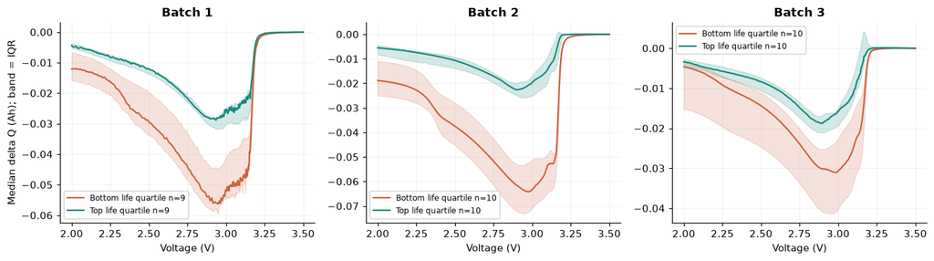

|  | batch | group | n | life_q25_cut | life_q75_cut | life_min | life_max | median_log_dq_var |
| --- | --- | --- | --- | --- | --- | --- | --- | --- |
| 0 | Batch 1 | Bottom life quartile | 9 | 681.00 | 871.50 | 534.0 | 651.0 | -3.433 |
| 1 | Batch 1 | Top life quartile | 9 | 681.00 | 871.50 | 876.0 | 1074.0 | -4.046 |
| 2 | Batch 2 | Bottom life quartile | 10 | 439.50 | 508.50 | 392.0 | 437.0 | -3.339 |
| 3 | Batch 2 | Top life quartile | 10 | 439.50 | 508.50 | 514.0 | 1186.0 | -4.231 |
| 4 | Batch 3 | Bottom life quartile | 10 | 827.25 | 1122.75 | 541.0 | 825.0 | -3.975 |
| 5 | Batch 3 | Top life quartile | 10 | 827.25 | 1122.75 | 1146.0 | 1935.0 | -4.417 |

```python
fig, relative = review.relative_delta(cells, features, OUT)
plt.show()
display(relative.round(3))
```

## Q4. 충전 조건과 수명의 관계는?

프로토콜의 C1, 전환 SOC, C2를 분리한다. `(new)` 표시는 원문의 `-newstructure`이며 삭제하지 않고 구분한다. 단순한 C1 평균이 아니라 0~80% SOC 두 단계의 등가 C-rate를 사용한다: `C_eq = 0.8 / [p/C1 + (0.8-p)/C2]`, p=전환 SOC/100. 휴지·CV·특수 프로토콜에는 동일한 해석을 강제하지 않는다.

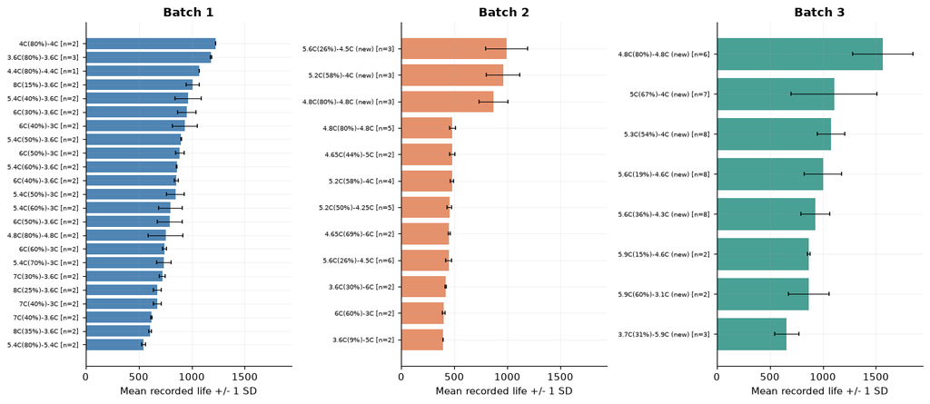

|  | batch | policy | n | mean | median | std |
| --- | --- | --- | --- | --- | --- | --- |
| 0 | Batch 1 | 3.6C(80%)-3.6C | 3 | 1182.00 | 1179.0 | 7.00 |
| 1 | Batch 1 | 4.4C(80%)-4.4C | 1 | 1074.00 | 1074.0 | NaN |
| 2 | Batch 1 | 4.8C(80%)-4.8C | 2 | 753.00 | 753.0 | 165.46 |
| 3 | Batch 1 | 4C(80%)-4C | 2 | 1226.50 | 1226.5 | 0.71 |
| 4 | Batch 1 | 5.4C(40%)-3.6C | 2 | 966.50 | 966.5 | 123.74 |
| 5 | Batch 1 | 5.4C(50%)-3.6C | 2 | 899.50 | 899.5 | 3.54 |
| 6 | Batch 1 | 5.4C(50%)-3C | 2 | 847.00 | 847.0 | 83.44 |
| 7 | Batch 1 | 5.4C(60%)-3.6C | 2 | 859.50 | 859.5 | 3.54 |
| 8 | Batch 1 | 5.4C(60%)-3C | 2 | 799.50 | 799.5 | 113.84 |
| 9 | Batch 1 | 5.4C(70%)-3C | 2 | 739.50 | 739.5 | 68.59 |
| 10 | Batch 1 | 5.4C(80%)-5.4C | 2 | 546.50 | 546.5 | 17.68 |
| 11 | Batch 1 | 6C(30%)-3.6C | 2 | 952.50 | 952.5 | 86.97 |
| 12 | Batch 1 | 6C(40%)-3.6C | 2 | 856.00 | 856.0 | 19.80 |
| 13 | Batch 1 | 6C(40%)-3C | 2 | 935.50 | 935.5 | 115.26 |
| 14 | Batch 1 | 6C(50%)-3.6C | 2 | 792.50 | 792.5 | 118.09 |
| 15 | Batch 1 | 6C(50%)-3C | 2 | 888.50 | 888.5 | 40.31 |
| 16 | Batch 1 | 6C(60%)-3C | 2 | 744.00 | 744.0 | 18.38 |
| 17 | Batch 1 | 7C(30%)-3.6C | 2 | 722.50 | 722.5 | 27.58 |
| 18 | Batch 1 | 7C(40%)-3.6C | 2 | 621.00 | 621.0 | 5.66 |
| 19 | Batch 1 | 7C(40%)-3C | 2 | 676.00 | 676.0 | 39.60 |
| 20 | Batch 1 | 8C(15%)-3.6C | 2 | 1008.50 | 1008.5 | 60.10 |
| 21 | Batch 1 | 8C(25%)-3.6C | 2 | 676.50 | 676.5 | 36.06 |
| 22 | Batch 1 | 8C(35%)-3.6C | 2 | 607.50 | 607.5 | 12.02 |
| 23 | Batch 2 | 3.6C(30%)-6C | 2 | 421.00 | 421.0 | 7.07 |
| 24 | Batch 2 | 3.6C(9%)-5C | 2 | 394.50 | 394.5 | 2.12 |
| 25 | Batch 2 | 4.65C(44%)-5C | 2 | 482.50 | 482.5 | 23.33 |
| 26 | Batch 2 | 4.65C(69%)-6C | 2 | 452.00 | 452.0 | 11.31 |
| 27 | Batch 2 | 4.8C(80%)-4.8C | 5 | 483.60 | 492.0 | 30.32 |
| 28 | Batch 2 | 4.8C(80%)-4.8C-newstructure | 3 | 871.67 | 809.0 | 137.19 |
| 29 | Batch 2 | 5.2C(50%)-4.25C | 5 | 454.00 | 449.0 | 20.92 |
| 30 | Batch 2 | 5.2C(58%)-4C | 4 | 477.75 | 483.0 | 18.46 |
| 31 | Batch 2 | 5.2C(58%)-4C-newstructure | 3 | 961.67 | 904.0 | 157.62 |
| 32 | Batch 2 | 5.6C(26%)-4.5C | 6 | 448.50 | 446.0 | 29.13 |
| 33 | Batch 2 | 5.6C(26%)-4.5C-newstructure | 3 | 991.33 | 997.0 | 197.56 |
| 34 | Batch 2 | 6C(60%)-3C | 2 | 400.00 | 400.0 | 11.31 |
| 35 | Batch 3 | 3.7C(31%)-5.9C-newstructure | 3 | 660.00 | 667.0 | 115.66 |
| 36 | Batch 3 | 4.8C(80%)-4.8C-newstructure | 6 | 1564.17 | 1640.0 | 285.72 |
| 37 | Batch 3 | 5.3C(54%)-4C-newstructure | 8 | 1074.38 | 1051.0 | 129.67 |
| 38 | Batch 3 | 5.6C(19%)-4.6C-newstructure | 8 | 1001.38 | 1038.0 | 174.56 |
| 39 | Batch 3 | 5.6C(36%)-4.3C-newstructure | 8 | 930.88 | 890.5 | 135.02 |
| 40 | Batch 3 | 5.9C(15%)-4.6C-newstructure | 2 | 867.00 | 867.0 | 12.73 |
| 41 | Batch 3 | 5.9C(60%)-3.1C-newstructure | 2 | 866.50 | 866.5 | 191.63 |
| 42 | Batch 3 | 5C(67%)-4C-newstructure | 7 | 1105.71 | 1009.0 | 402.91 |

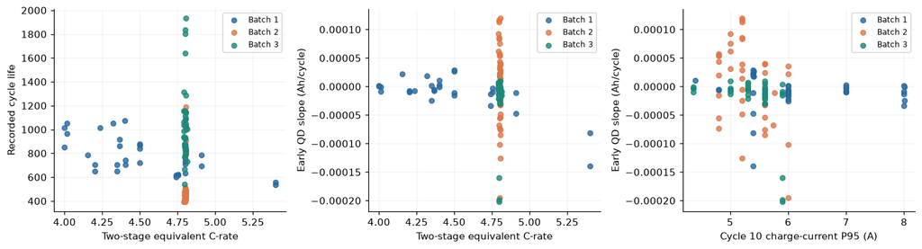

|  | batch | x | y | n | pearson | spearman |
| --- | --- | --- | --- | --- | --- | --- |
| 0 | Batch 1 | c_equiv | qd_slope | 36 | -0.617 | -0.464 |
| 1 | Batch 1 | current10_p95_A | qd_slope | 36 | -0.016 | -0.217 |
| 2 | Batch 2 | c_equiv | qd_slope | 39 | -0.333 | -0.432 |
| 3 | Batch 2 | current10_p95_A | qd_slope | 39 | -0.404 | -0.358 |
| 4 | Batch 3 | c_equiv | qd_slope | 40 | 0.269 | -0.073 |
| 5 | Batch 3 | current10_p95_A | qd_slope | 40 | -0.374 | -0.445 |

```python
da.fig_policy(features, OUT)
plt.show()
display(da.policy_table(features).round(2))
da.fig_rate(features, OUT)
plt.show()
display(pd.read_csv(OUT / "tables/rate_fade_correlations.csv").round(3))
```

**관찰:** Batch 1에서는 C_eq-수명 r=-0.580이지만 Batch 2는 +0.334, Batch 3는 -0.020이다. Batch 3의 C_eq 범위는 약 4.794~4.813으로 매우 좁다. Batch 2의 동일한 `4.8C(80%)-4.8C`도 일반 프로토콜 평균 483.6(n=5), newstructure 평균 871.7(n=3)으로 다르다. 구조/실험 조건이 함께 달라질 수 있다.

**해석:** '빠른 충전이면 언제나 단수명'이라는 전역 결론을 낼 수 없다. 표준편차 막대는 평균의 신뢰구간이 아니며 n=1이면 표준편차를 추정할 수 없다. 실측 전류는 사이클 10 양의 전류의 95백분위수로 요약했고, 초기 QD 기울기와의 관계도 Batch별로 달랐다.

**시사점:** 정책을 검증 그룹으로 사용하고 C_eq는 보조 피처 후보로 비교한다. newstructure의 정확한 물리적 의미를 자료만으로 지어내지 않는다.

**실측 충전 패턴 확인:** cycle 10에서 각 Batch의 최단·중앙 순위·최장 셀 전류를 직접 비교한다. 첫 양의 충전 전류부터 첫 음의 방전 전류 직전까지 표시한다. 패턴은 단계 전환과 후반 전류 감소를 보여준다. P95는 양의 전류 샘플의 크기 요약으로, 시간 가중 평균이나 충전 에너지·충전율 전체를 대신하지 않는다. 전류-초기 열화 상관은 위 표에서 확인하며, 전류 패턴만으로 개별 수명 차이의 원인을 확정하지 않는다.

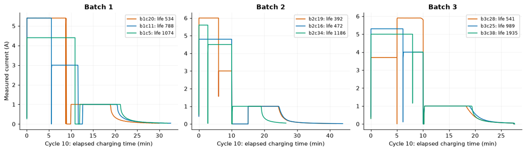

|  | cell_id | batch | cycle | samples | charge_window_minutes | positive_current_p95_A | policy |
| --- | --- | --- | --- | --- | --- | --- | --- |
| 0 | b1c20 | Batch 1 | 10 | 608 | 29.915 | 5.401 | 5.4C(80%)-5.4C |
| 1 | b1c11 | Batch 1 | 10 | 643 | 32.581 | 5.401 | 5.4C(50%)-3C |
| 2 | b1c5 | Batch 1 | 10 | 622 | 31.930 | 4.400 | 4.4C(80%)-4.4C |
| 3 | b2c19 | Batch 2 | 10 | 580 | 41.919 | 6.002 | 6C(60%)-3C |
| 4 | b2c16 | Batch 2 | 10 | 601 | 43.911 | 4.801 | 4.8C(80%)-4.8C |
| 5 | b2c34 | Batch 2 | 10 | 410 | 26.589 | 5.602 | 5.6C(26%)-4.5C-newstructure |
| 6 | b3c28 | Batch 3 | 10 | 435 | 27.438 | 5.900 | 3.7C(31%)-5.9C-newstructure |
| 7 | b3c25 | Batch 3 | 10 | 427 | 27.499 | 5.301 | 5.3C(54%)-4C-newstructure |
| 8 | b3c38 | Batch 3 | 10 | 424 | 27.589 | 5.001 | 5C(67%)-4C-newstructure |

```python
fig, current = review.current_patterns(cells, features, OUT)
plt.show()
display(current.round(3))
```

## Q5. 어떤 신호가 수명과 연관되는가?

Pearson은 선형 관계, Spearman은 순위 관계를 본다. 전체 pooled 값과 Batch별 값을 함께 확인해야 Batch 차이를 피처 효과로 오인하지 않는다.

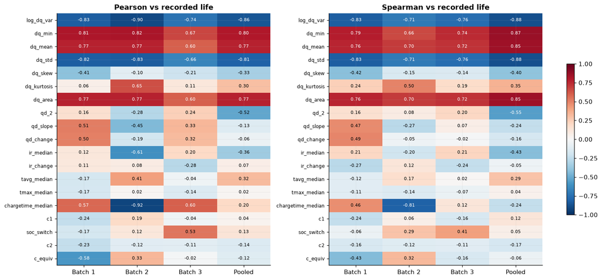

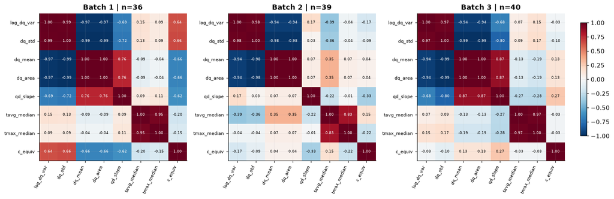

```python
da.fig_correlations(corr, OUT)
plt.show()
fig, feature_pairs = review.collinearity(features, OUT)
plt.show()
```

**관찰:** ΔQ 로그분산은 안정적인 음의 연관성을 보인다. 충전시간은 +0.571/-0.919/+0.599로 방향이 바뀐다. 초기 QD 기울기도 +0.508/-0.445/+0.331이다. Batch 1에서 Tavg-Tmax r=0.949, log_dq_var-dq_std r=0.991, ΔQ 평균-면적 r≈1이다. log10 Var=2log10 Std이므로 분산과 표준편차는 독립 정보가 아니다.

**해석:** 높은 pooled 상관계수 하나로 피처를 선택하면 Batch 교란과 중복을 놓친다. 온도·저항은 단독 상관이 약하다고 모든 정보를 배제할 수는 없으나, 작은 표본에서 우선순위를 낮춘다.

**시사점:** 소수 피처와 규제가 필요하다. ΔQ 파생 피처는 대표 하나를 우선 사용하고, 보조 피처는 학습 Batch 내부 교차검증의 추가 효과로 결정한다.

**핵심 피처 분포와 최강 관계 점검:** 박스는 중앙값·IQR, 점은 셀이다. 전처리 전의 실제 분포를 비교한다. 배치별 범위 차이를 확인한 후 대치·표준화는 반드시 학습 fold에서만 적합한다. 아래 표는 각 Batch의 절대 Pearson/Spearman 상관 상위 3개를 각각 보여준다. 최고 순위와 여러 Batch에 걸친 안정성을 구분하며, 안정성과 단순성을 이유로 log_dq_var를 주피처로 선택한다.

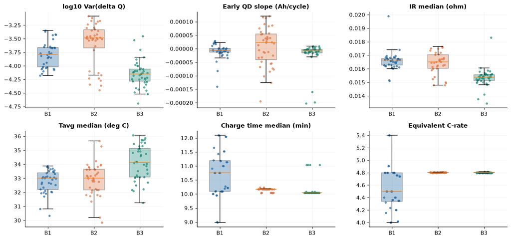

|  | batch | feature | n | missing | min | q25 | median | q75 | max |
| --- | --- | --- | --- | --- | --- | --- | --- | --- | --- |
| 0 | Batch 1 | log_dq_var | 36 | 0 | -4.17844 | -4.02000 | -3.78604 | -3.66148 | -3.34990 |
| 1 | Batch 2 | log_dq_var | 39 | 0 | -4.44815 | -3.67366 | -3.48683 | -3.33513 | -3.08545 |
| 2 | Batch 3 | log_dq_var | 40 | 0 | -4.69408 | -4.28750 | -4.15047 | -4.05895 | -3.45122 |
| 3 | Batch 1 | qd_slope | 36 | 0 | -0.00014 | -0.00001 | -0.00001 | 0.00000 | 0.00003 |
| 4 | Batch 2 | qd_slope | 39 | 0 | -0.00019 | -0.00004 | 0.00002 | 0.00005 | 0.00012 |
| 5 | Batch 3 | qd_slope | 40 | 0 | -0.00020 | -0.00002 | -0.00001 | -0.00000 | 0.00001 |
| 6 | Batch 1 | ir_median | 36 | 0 | 0.01511 | 0.01626 | 0.01663 | 0.01676 | 0.01989 |
| 7 | Batch 2 | ir_median | 33 | 6 | 0.01479 | 0.01602 | 0.01650 | 0.01705 | 0.01764 |
| 8 | Batch 3 | ir_median | 40 | 0 | 0.01344 | 0.01513 | 0.01537 | 0.01557 | 0.01831 |
| 9 | Batch 1 | tavg_median | 36 | 0 | 30.34183 | 32.19892 | 32.99780 | 33.38147 | 33.87271 |
| 10 | Batch 2 | tavg_median | 39 | 0 | 29.84982 | 32.16488 | 33.01905 | 33.63729 | 35.67533 |
| 11 | Batch 3 | tavg_median | 40 | 0 | 31.24566 | 33.08410 | 34.12823 | 35.13749 | 36.06830 |
| 12 | Batch 1 | chargetime_median | 36 | 0 | 8.98574 | 10.09681 | 10.76368 | 11.18669 | 12.09831 |
| 13 | Batch 2 | chargetime_median | 39 | 0 | 10.03561 | 10.16982 | 10.17375 | 10.17698 | 10.23871 |
| 14 | Batch 3 | chargetime_median | 40 | 0 | 10.04128 | 10.04236 | 10.04323 | 10.04416 | 11.04020 |
| 15 | Batch 1 | c_equiv | 36 | 0 | 4.00000 | 4.34038 | 4.50000 | 4.80000 | 5.40000 |
| 16 | Batch 2 | c_equiv | 39 | 0 | 4.79042 | 4.80000 | 4.80000 | 4.80370 | 4.80687 |
| 17 | Batch 3 | c_equiv | 40 | 0 | 4.79367 | 4.79517 | 4.80160 | 4.80373 | 4.81316 |

|  | batch | feature | n | pearson |
| --- | --- | --- | --- | --- |
| 128 | Batch 2 | chargetime_median | 39 | -0.919118 |
| 114 | Batch 2 | log_dq_var | 39 | -0.901883 |
| 117 | Batch 2 | dq_std | 39 | -0.834546 |
| 95 | Batch 1 | log_dq_var | 36 | -0.826584 |
| 98 | Batch 1 | dq_std | 36 | -0.821493 |
| 96 | Batch 1 | dq_min | 36 | 0.805061 |
| 133 | Batch 3 | log_dq_var | 40 | -0.741661 |
| 134 | Batch 3 | dq_min | 40 | 0.665106 |
| 136 | Batch 3 | dq_std | 40 | -0.663699 |

|  | batch | feature | n | spearman |
| --- | --- | --- | --- | --- |
| 95 | Batch 1 | log_dq_var | 36 | -0.826232 |
| 98 | Batch 1 | dq_std | 36 | -0.826232 |
| 128 | Batch 2 | chargetime_median | 39 | -0.809900 |
| 96 | Batch 1 | dq_min | 36 | 0.786716 |
| 136 | Batch 3 | dq_std | 40 | -0.758608 |
| 133 | Batch 3 | log_dq_var | 40 | -0.758608 |
| 134 | Batch 3 | dq_min | 40 | 0.744066 |
| 117 | Batch 2 | dq_std | 39 | -0.708979 |
| 114 | Batch 2 | log_dq_var | 39 | -0.708979 |

|  | batch | feature_x | feature_y | pearson | n | abs_r_ge_0_9 |
| --- | --- | --- | --- | --- | --- | --- |
| 38 | Batch 1 | dq_mean | dq_area | 1.000 | 36 | True |
| 22 | Batch 1 | dq_min | dq_area | 0.992 | 36 | True |
| 18 | Batch 1 | dq_min | dq_mean | 0.992 | 36 | True |
| 2 | Batch 1 | log_dq_var | dq_std | 0.991 | 36 | True |
| 116 | Batch 1 | qd_slope | qd_change | 0.988 | 36 | True |
| 150 | Batch 1 | tavg_median | tmax_median | 0.949 | 36 | True |
| 1 | Batch 1 | log_dq_var | dq_mean | -0.971 | 36 | True |
| 5 | Batch 1 | log_dq_var | dq_area | -0.971 | 36 | True |
| 35 | Batch 1 | dq_mean | dq_std | -0.986 | 36 | True |
| 53 | Batch 1 | dq_std | dq_area | -0.986 | 36 | True |
| 0 | Batch 1 | log_dq_var | dq_min | -0.988 | 36 | True |
| 164 | Batch 1 | chargetime_median | c_equiv | -0.994 | 36 | True |
| 19 | Batch 1 | dq_min | dq_std | -0.997 | 36 | True |
| 209 | Batch 2 | dq_mean | dq_area | 1.000 | 39 | True |
| 173 | Batch 2 | log_dq_var | dq_std | 0.980 | 39 | True |
| 193 | Batch 2 | dq_min | dq_area | 0.979 | 39 | True |
| 189 | Batch 2 | dq_min | dq_mean | 0.979 | 39 | True |
| 184 | Batch 2 | log_dq_var | chargetime_median | 0.946 | 39 | True |
| 287 | Batch 2 | qd_slope | qd_change | 0.904 | 39 | True |
| 172 | Batch 2 | log_dq_var | dq_mean | -0.943 | 39 | True |
| 176 | Batch 2 | log_dq_var | dq_area | -0.943 | 39 | True |
| 171 | Batch 2 | log_dq_var | dq_min | -0.975 | 39 | True |
| 206 | Batch 2 | dq_mean | dq_std | -0.981 | 39 | True |
| 224 | Batch 2 | dq_std | dq_area | -0.981 | 39 | True |
| 190 | Batch 2 | dq_min | dq_std | -0.997 | 39 | True |
| 380 | Batch 3 | dq_mean | dq_area | 1.000 | 40 | True |
| 458 | Batch 3 | qd_slope | qd_change | 0.996 | 40 | True |
| 364 | Batch 3 | dq_min | dq_area | 0.988 | 40 | True |
| 360 | Batch 3 | dq_min | dq_mean | 0.988 | 40 | True |
| 344 | Batch 3 | log_dq_var | dq_std | 0.974 | 40 | True |
| 492 | Batch 3 | tavg_median | tmax_median | 0.969 | 40 | True |
| 343 | Batch 3 | log_dq_var | dq_mean | -0.941 | 40 | True |
| 347 | Batch 3 | log_dq_var | dq_area | -0.941 | 40 | True |
| 342 | Batch 3 | log_dq_var | dq_min | -0.968 | 40 | True |
| 377 | Batch 3 | dq_mean | dq_std | -0.987 | 40 | True |
| 395 | Batch 3 | dq_std | dq_area | -0.987 | 40 | True |
| 361 | Batch 3 | dq_min | dq_std | -0.998 | 40 | True |

|  | scope | batch | feature | n | pearson | spearman |
| --- | --- | --- | --- | --- | --- | --- |
| 0 | all_labeled | Pooled | log_dq_var | 129 | -0.851 | -0.892 |
| 1 | all_labeled | Pooled | qd_slope | 129 | -0.089 | -0.159 |
| 2 | all_labeled | Pooled | chargetime_median | 129 | 0.315 | -0.028 |
| 3 | all_labeled | Batch 1 | log_dq_var | 46 | -0.886 | -0.871 |
| 4 | all_labeled | Batch 1 | qd_slope | 46 | 0.541 | 0.580 |
| 5 | all_labeled | Batch 1 | chargetime_median | 46 | 0.744 | 0.641 |
| 6 | all_labeled | Batch 2 | log_dq_var | 39 | -0.902 | -0.709 |
| 7 | all_labeled | Batch 2 | qd_slope | 39 | -0.445 | -0.271 |
| 8 | all_labeled | Batch 2 | chargetime_median | 39 | -0.919 | -0.810 |
| 9 | all_labeled | Batch 3 | log_dq_var | 44 | -0.702 | -0.797 |
| 10 | all_labeled | Batch 3 | qd_slope | 44 | 0.338 | 0.088 |
| 11 | all_labeled | Batch 3 | chargetime_median | 44 | 0.638 | 0.261 |
| 12 | quality_screened | Pooled | log_dq_var | 115 | -0.857 | -0.879 |
| 13 | quality_screened | Pooled | qd_slope | 115 | -0.127 | -0.235 |
| 14 | quality_screened | Pooled | chargetime_median | 115 | 0.202 | -0.236 |
| 15 | quality_screened | Batch 1 | log_dq_var | 36 | -0.827 | -0.826 |
| 16 | quality_screened | Batch 1 | qd_slope | 36 | 0.508 | 0.473 |
| 17 | quality_screened | Batch 1 | chargetime_median | 36 | 0.571 | 0.461 |
| 18 | quality_screened | Batch 2 | log_dq_var | 39 | -0.902 | -0.709 |
| 19 | quality_screened | Batch 2 | qd_slope | 39 | -0.445 | -0.271 |
| 20 | quality_screened | Batch 2 | chargetime_median | 39 | -0.919 | -0.810 |
| 21 | quality_screened | Batch 3 | log_dq_var | 40 | -0.742 | -0.759 |
| 22 | quality_screened | Batch 3 | qd_slope | 40 | 0.331 | 0.066 |
| 23 | quality_screened | Batch 3 | chargetime_median | 40 | 0.599 | 0.124 |

```python
fig, distribution = review.feature_distributions(features, OUT)
plt.show()
display(distribution.round(5))
for method in ["pearson", "spearman"]:
    ranked = corr[corr.scope.eq("quality_screened") & corr.batch.ne("Pooled")].copy()
    ranked["abs_r"] = ranked[method].abs()
    display(ranked.sort_values("abs_r", ascending=False).groupby("batch").head(3)[["batch", "feature", "n", method]])
display(feature_pairs[feature_pairs.abs_r_ge_0_9].sort_values(["batch", "pearson"], ascending=[True, False]).round(3))
display(pd.read_csv(OUT / "tables/screening_sensitivity.csv").round(3))
```

## 모델 설계 전략: 초기 100사이클 회귀

**타깃:** 제공 `cycle_life`(사이클). 학습에서는 `log10(cycle_life)` 변환을 비교하고 예측을 원래 단위로 복원해 평가한다. 500 기준 분류는 Batch 1이 0:46(주분석 0:36)로 불균형이 심하다. 단수명 표본이 없어 안정적인 분류 검증이 어렵고 수치 예측의 운영 활용도도 높아 회귀를 선택한다.

**피처 계획**

| 집합 | 피처 | EDA 근거 |
| --- | --- | --- |
| F1 주안 | log_dq_var | 세 Batch에서 방향 일치, 한 개 대표 변수 |
| F2 비교 | F1 + qd_slope + c_equiv | 초기 변화와 정책 보완, Batch 1 내부 검증으로 추가 가치 판정 |
| F3 민감도 | F2 + tavg_median + ir_median | 온도/저항의 조합 효과만 제한적으로 확인 |
| 우선 제외 | dq_std, dq_mean, dq_area, Tmax 동시 투입 | 다중공선성/중복 |
| 보류 | 충전시간, 정책 문자열 원핫, newstructure | Batch별 부호 변화/희소 범주/학습 Batch에 없는 조건 |
| 입력 금지 | cell_id, batch, cycle_life 파생값, n_cycles, last_qd, knee | 식별자·정답·미래 정보 |

**후보 모델을 EDA와 연결**

1. DummyRegressor 중앙값: 실제로 배웠는지 확인할 기준선.
2. Ridge / ElasticNet: 표본이 작고 ΔQ 파생량이 중복되므로 규제 선형 모델 우선.
3. 얕은 RandomForest: 비선형 비교군. max_depth 2~3, min_samples_leaf 3~5; 학습 범위 밖 수명 외삽에 한계.

모델 적합과 성능 비교는 DAY 2에 수행한다. DAY 1 산출물에 미측정 성능을 적지 않는다.

```python
split = pd.read_csv(OUT / "tables/planned_split.csv")
display(split.groupby("planned_split").agg(cells=("cell_id", "size"), policies=("policy", "nunique")))
display(split)
assert not set(split[split.planned_split.eq("train")].policy) & set(split[split.planned_split.eq("validation")].policy)
print("PASS: 정책 그룹과 셀 ID가 train/validation에 겹치지 않는다.")
```

| planned_split | cells | policies |
| --- | --- | --- |
| train | 29 | 16 |
| validation | 7 | 4 |

|  | cell_id | policy | planned_split | cv_fold |
| --- | --- | --- | --- | --- |
| 0 | b1c5 | 4.4C(80%)-4.4C | validation | -1 |
| 1 | b1c6 | 4.8C(80%)-4.8C | validation | -1 |
| 2 | b1c7 | 4.8C(80%)-4.8C | validation | -1 |
| 3 | b1c9 | 5.4C(40%)-3.6C | train | 3 |
| 4 | b1c11 | 5.4C(50%)-3C | train | 2 |
| 5 | b1c14 | 5.4C(60%)-3C | train | 3 |
| 6 | b1c15 | 5.4C(60%)-3C | train | 3 |
| 7 | b1c16 | 5.4C(60%)-3.6C | train | 0 |
| 8 | b1c17 | 5.4C(60%)-3.6C | train | 0 |
| 9 | b1c18 | 5.4C(70%)-3C | train | 2 |
| 10 | b1c19 | 5.4C(70%)-3C | train | 2 |
| 11 | b1c20 | 5.4C(80%)-5.4C | train | 1 |
| 12 | b1c21 | 5.4C(80%)-5.4C | train | 1 |
| 13 | b1c23 | 6C(30%)-3.6C | train | 1 |
| 14 | b1c24 | 6C(40%)-3C | train | 3 |
| 15 | b1c25 | 6C(40%)-3C | train | 3 |
| 16 | b1c26 | 6C(40%)-3.6C | train | 0 |
| 17 | b1c27 | 6C(40%)-3.6C | train | 0 |
| 18 | b1c28 | 6C(50%)-3C | train | 1 |
| 19 | b1c29 | 6C(50%)-3C | train | 1 |
| 20 | b1c30 | 6C(50%)-3.6C | train | 2 |
| 21 | b1c31 | 6C(50%)-3.6C | train | 2 |
| 22 | b1c32 | 6C(60%)-3C | train | 0 |
| 23 | b1c33 | 6C(60%)-3C | train | 0 |
| 24 | b1c34 | 7C(30%)-3.6C | train | 3 |
| 25 | b1c35 | 7C(30%)-3.6C | train | 3 |
| 26 | b1c36 | 7C(40%)-3C | train | 2 |
| 27 | b1c37 | 7C(40%)-3C | train | 2 |
| 28 | b1c38 | 7C(40%)-3.6C | validation | -1 |
| 29 | b1c39 | 7C(40%)-3.6C | validation | -1 |
| 30 | b1c40 | 8C(15%)-3.6C | validation | -1 |
| 31 | b1c41 | 8C(15%)-3.6C | validation | -1 |
| 32 | b1c42 | 8C(25%)-3.6C | train | 1 |
| 33 | b1c43 | 8C(25%)-3.6C | train | 1 |
| 34 | b1c44 | 8C(35%)-3.6C | train | 0 |
| 35 | b1c45 | 8C(35%)-3.6C | train | 0 |

```
PASS: 정책 그룹과 셀 ID가 train/validation에 겹치지 않는다.
```

## DAY 2 실행 설계와 평가의 한계

- Batch 1 주분석 36개를 정책 단위 GroupShuffleSplit(test_size=0.2, random_state=42) → train 29개/16정책, validation 7개/4정책.
- Train 안에서 4-fold GroupKFold. 결측 대치·StandardScaler·피처 선택을 각 fold의 train에만 fit하는 Pipeline 사용.
- 후보: Ridge alpha [0.1,1,10,100], ElasticNet alpha [0.001,0.01,0.1]와 l1_ratio [0.2,0.8]; 좁은 탐색으로 과도한 튜닝 방지.
- 모델/피처 집합을 train CV로 고른 뒤 validation을 한 번 확인. 절차 동결 후 Batch 1 36개로 재학습, Batch 2 39개, Batch 3 40개에서 평가.
- 주지표 MAPE(%), 보조 MAE/RMSE(사이클), R². 수명 구간별 잔차 및 큰 오차 셀을 공개.
- DAY 1 요구사항 때문에 Batch 2·3의 정답 분포/상관을 이미 관찰했다. 따라서 향후 평가는 **EDA에서 관찰한 외부 Batch 평가**이며 완전한 블라인드 테스트가 아니다. 새 미관찰 배치로 후속 검증해야 한다.
- Batch 1 내부 validation 역시 전체 Batch 1 EDA 후 설계됐다는 한계를 명시한다.
- 논문 9.1%는 다른 정제/분할 조건의 참고 성능이다. 직접 재현 성능이나 달성 보장으로 쓰지 않는다.

ESS 활용은 셀 수명 선별·교체 계획의 연구 단계이다. 실제 ESS의 온도, 부하, 달력 열화, 팩 불균형 조건은 추가 검증이 필요하다. 운영 시 피처 분포 변화(Data Drift), 정답 확보 후 오차 증가(Model Drift)를 모니터링하고 새 Batch 검증 후 재학습한다.

```python
# 산출물 누락 검증 (학습은 하지 않음)
expected = ["01_life_distribution", "02_degradation", "03_representatives_knee", "04_delta_curves", "05_delta_groups", "06_feature_scatter", "07_policy_means", "08_rate_and_fade", "09_correlations", "10_collinearity", "11_early_cycles", "12_feature_distributions", "13_delta_relative_groups", "14_current_patterns"]
for name in expected:
    assert (OUT / "figures" / f"{name}.png").stat().st_size > 1000
assert len(features[features.analysis_eligible]) == 115
print("PASS: 필수 그래프 11개 + PDF용 정책 그래프 3개 + 보완 그래프 3개, 표, 분리 계획 생성 완료")
```

```
PASS: 필수 그래프 11개 + PDF용 정책 그래프 3개 + 보완 그래프 3개, 표, 분리 계획 생성 완료
```

## 참고자료와 다음 읽기 순서

1. 교수님 제공 `30-ESSHealth-scratch.ipynb`, DAY 1 과제 화면 3장, 저장된 강의 webarchive.
2. Severson et al. (2019), Nature Energy 4, 383–391. https://doi.org/10.1038/s41560-019-0356-8
3. 저자 공개 코드: https://github.com/rdbraatz/data-driven-prediction-of-battery-cycle-life-before-capacity-degradation

먼저 Q1의 Batch 차이 → Q3의 ΔQ 핵심 신호 → Q5의 피처 중복 → 모델 설계 순서로 이해하면 전체 흐름을 잡기 쉽다. 분석/문서 초안에 AI 도구를 활용했으며 제출자는 수치와 해석을 확인하고 설명할 수 있어야 한다.